# Simulations of Stock-Recruit data

Maria Kuruvilla

June 2025

# 1 Goal

Determine the accuracy of the estimates of Stock-Recruitment model parameters by using simulated data from Beverton-Holt and Ricker models.

## 1.1 Generating Recruit Time Series

We generated data using the Beverton Holt equation and the Ricker equation for 50 years and with initial population size of 100.

### 1.1.1 Beverton-Holt Equation

$N_{t+1} = N_t \ \frac{e^{\alpha + \beta Forestry + \epsilon}}{1 + \frac{e^{\alpha}N_t}{R_k}} \$

$R_K = \frac{K}{e^{\alpha}-1}$

### 1.1.2 Ricker Equation

$N_{t+1} = N_t \ e^{\alpha - \frac{N_{t}}{S_{max}} + \beta Forestry + \epsilon}$

$S_{max} = \frac{K}{\alpha}$

$\epsilon \sim N(0,\sigma)$

We used $K = 1000$, $Forestry = \sqrt{CPD}$ of Carnation Creek and varied $\alpha$, $\sigma$, and $\beta$.

We discarded data in which the population crashed ($<1$). This occurred when $\alpha$ was high in the Ricker model. We fit the model with normal prior for $\alpha \sim N(5,10)$ and $0<\alpha<10$ constraint.

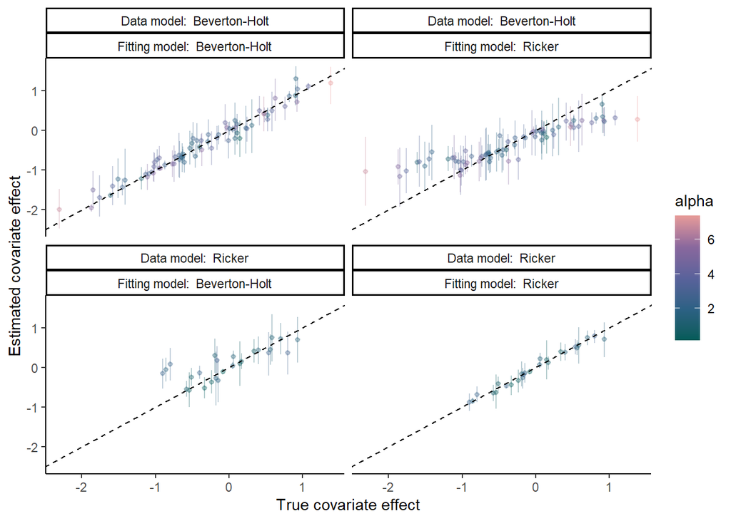

When the Ricker model is fit to Beverton-Holt data (and perhaps vice versa), the effect of a covariate is underestimated.

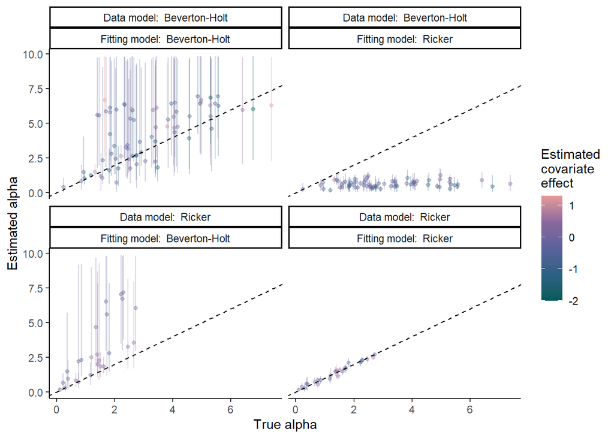

The Ricker model is able to estimate $\alpha$ from data generated from the Ricker model. The Ricker model underestimates $\alpha$ values from Beverton-Holt data. The Beverton-Holt model is unable to estimate $\alpha$ precisely.

## 1.2 Generating $ln(\frac{R}{S})$ data

To overcome the chaotic dynamics of the Ricker model at high values of $\alpha$, we generated $\ln(\frac{R}{S})$ data by using empirical spawner data from Carnation Creek.

### 1.2.1 Beverton-Holt Equation

$R_K = \frac{K}{e^{\alpha}-1}$

### 1.2.2 Ricker Equation

$\ln(\frac{R}{S}) = \alpha - \frac{S}{S_{max}} + \beta Forestry + \epsilon$

$S_{max} = \frac{K}{\alpha}$

$\epsilon \sim N(0,\sigma)$

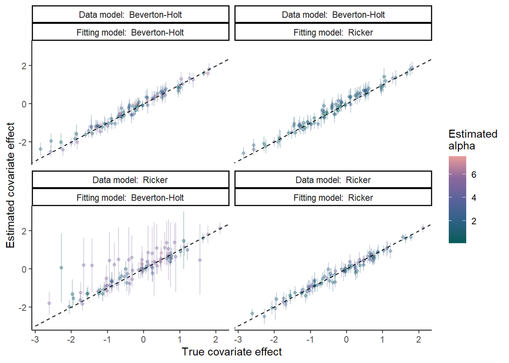

The estimate of covariate effect is usually accurate. It can have high levels of uncertainty when fitting Beverton-Holt data to Ricker data which coincides with high estimated $\alpha$ values.

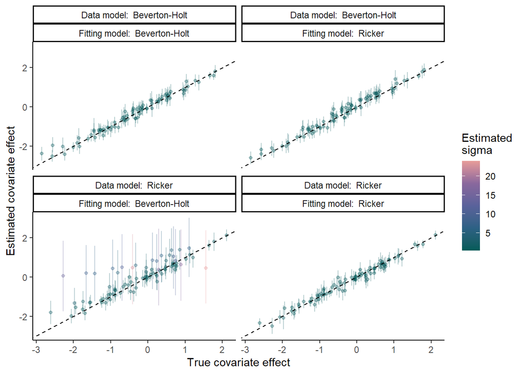

The estimate of covariate effect is usually accurate. It can have high levels of uncertainty when fitting Beverton-Holt data to Ricker data which coincides with high estimated $\sigma$ values.

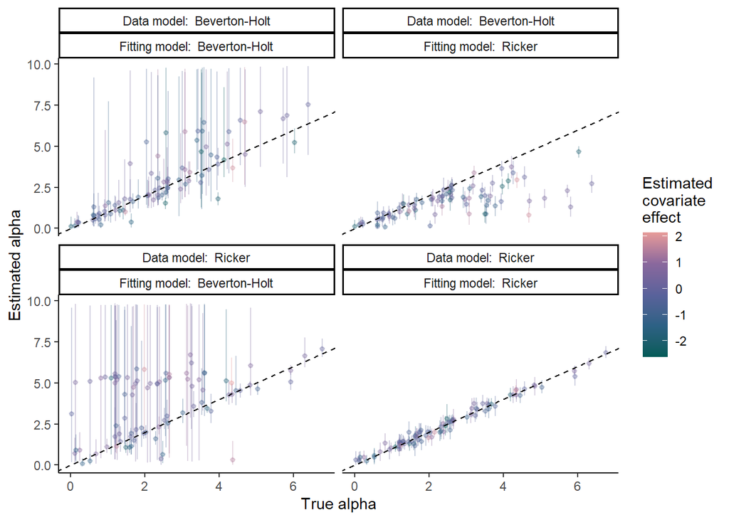

The Ricker model is able to estimate $\alpha$ from data generated from the Ricker model. The Ricker model underestimates $\alpha$ values from Beverton-Holt data. The Beverton-Holt model is unable to estimate $\alpha$ precisely.